# Pengenalan Analisis Regresi

Elardian Putera Ramadhan (G1401231042)

2025-02-06

# Pengenalan R

- R merupakan serangkaian fasilitas *software* yang terintegrasi untuk memanipulasi data, perhitungan, dan tampilan grafik.
- *Open Source*
- Analisis statistika di R berupa serangkaian *steps* dengan hasil yang disimpan dalam suatu objek.

## Objek Data dalam R

- Vektor
- Matriks
- Array
- Factor
- List
- Data Frame

### Vektor

Vektor merupakan tipe sederhana dari objek dan setiap elemen memiliki mode yang sama.

Contoh:

```r
a <- c(2, 4)
b <- c("laki-laki", "perempuan")
```

Perintah dalam vektor:

```r
#rep (pengulangan)
rep(a, 2)
```

```
## [1] 2 4 2 4
```

```r
rep(a, each = 2)
```

```
## [1] 2 2 4 4
```

```r
#seq (membuat suatu urutan)
seq(from = 3, to = 1)
```

```
## [1] 3 2 1
```

```r
seq(from = 1, to = 2, by = 0.5)
```

```
## [1] 1.0 1.5 2.0
```

```r
#is.vector (memeriksa suatu objek termasuk dalam vektor)
#as.vector (mengubah objek menjadi vektor)
#operator (+, -, /, ^, %, dll)
```

Akses elemen ke-i dalam suatu vektor

Contoh:

```r
angka <- c(2, 3, 4, 1)
angka
```

```
## [1] 2 3 4 1
```

```r
names(angka) <- c("a", "b", "c", "d")
```

Untuk mengakses 2 dapat menggunakan syntax angka[“a] atau angka[1]

```r
angka[2:3]
```

```
## b c
## 3 4
```

```r
angka[c(1, 4)]
```

```
## a d
## 2 1
```

```r
angka[angka < 2]
```

```
## d
## 1
```

```r
angka[-2]
```

```
## a c d
## 2 4 1
```

### Matriks

Matriks umumnya dibuat melalui vektor

Contoh:

```r
Data <- matrix(c(1, 2, 1, 100, 102, 103), nrow = 2,
               ncol = 3, byrow = TRUE,
               dimnames = list(c("row1", "row2"), c("C.1", "C.2", "C.3")))
Data
```

```
##      C.1 C.2 C.3
## row1   1   2   1
## row2 100 102 103
```

Perintah dalam vektor:

```r
#dim (mengetahui ukuran matriks)
#rbind (menggabungkan terhadap baris)
a <- c(2, 3, 4)
b <- c(1, 0, 1)
rbind(a, b)
```

```
##   [,1] [,2] [,3]
## a    2    3    4
## b    1    0    1
```

```r
#cbind (menggabungkan terhadap kolom)
a <- c(2, 3, 4)
b <- c(1, 0, 1)
cbind(a, b)
```

```
##      a b
## [1,] 2 1
## [2,] 3 0
## [3,] 4 1
```

Akses elemen dalam suatu matriks

Contoh:

```r
Data[1, 3]
```

```
## [1] 1
```

```r
Data[, 1]
```

```
## row1 row2
##    1  100
```

```r
Data[-1, -2]
```

```
## C.1 C.3
## 100 103
```

### Faktor

Faktor merupakan bentuk khusus dari vektor dengan elemen kategorik dan memiliki level.

Perintah dalam vektor:

```r
#factor (Konversi & mengatur level serta label)
x <- c("apple", "banana", "apple", "orange")
factor_x <- factor(x, levels = c("apple", "banana", "orange"), labels = c("A", "B", "C"))
print(factor_x)
```

```
## [1] A B A C
## Levels: A B C
```

```r
#as.factor (Konversi vektor menjadi faktor)
x <- c("apple", "banana", "apple", "orange")
factor_x <- as.factor(x)
print(factor_x)
```

```
## [1] apple  banana apple  orange
## Levels: apple banana orange
```

```r
#is.factor (Memeriksa data apakah faktor)
#Membuat vektor karakter
colors <- c("red", "green", "blue")

#Memeriksa apakah objek adalah faktor
is_colors_factor <- is.factor(colors)
print(is_colors_factor)
```

```
## [1] FALSE
```

### List

List merupakan struktur data yang dapat menyimpan berbagai jenis data dalam satu wadah.

```r
a <- c(2, 3, 4)
dt <- c("b", "a", "a")
Data <- matrix(c(1, 2, 1, 100, 102, 103), nrow = 2,
               ncol = 3, byrow = FALSE,
               dimnames = list(c("row1", "row2"), c("C.1", "C.2", "C.3")))
list(a, dt, Data)
```

```
## [[1]]
## [1] 2 3 4
##
## [[2]]
## [1] "b" "a" "a"
##
## [[3]]
##      C.1 C.2 C.3
## row1   1   1 102
## row2   2 100 103
```

### Data Frame

Merupakan bentuk khusus dari list untuk menyimpan data dari berbagai tipe dalam bentuk matriks.

Perintah yang umum digunakan dalam data frame:

data.frame() -> Membuat data frame baru dari vektor atau list

as.data.frame() -> Mengkonversi objek menjadi data frame

read.table() -> Membaca data dari file teks

Contoh:

```r
dtf <- data.frame(Mahasiswa = c("Amir", "Budi", "Citra"), JK = c("L", "L", "P"))
dtf
```

```
##   Mahasiswa JK
## 1      Amir  L
## 2      Budi  L
## 3     Citra  P
```

```r
dtf <- rbind(dtf, data.frame(Mahasiswa = "Intan", JK = "P"))
dtf
```

```
##   Mahasiswa JK
## 1      Amir  L
## 2      Budi  L
## 3     Citra  P
## 4     Intan  P
```

```r
colnames(dtf) #untuk mengetahui nama-nama kolom
```

```
## [1] "Mahasiswa" "JK"
```

```r
length(dtf) #untuk mengetahui jumlah kolom
```

```
## [1] 2
```

```r
dim(dtf) #untuk mengetahui jumlah dimensi
```

```
## [1] 4 2
```

```r
dtf[2] #atau dtf["JK] atau dtf$JK -> untuk mengakses semua elemen JK
```

```
##   JK
## 1  L
## 2  L
## 3  P
## 4  P
```

```r
dtf[1, ] #untuk mengakses baris ke-1 semua kolom
```

```
##   Mahasiswa JK
## 1      Amir  L
```

```r
dtf[2, 1] <- "Bambang"
dtf
```

```
##   Mahasiswa JK
## 1      Amir  L
## 2   Bambang  L
## 3     Citra  P
## 4     Intan  P
```

```r
names(dtf)[1] <- "Nama" #mengganti nama kolom ke-1
```

### Input Data Dalam R

- File .txt

data <- read.table(“C:/…./namadata.txt”, header = TRUE)

Jika pemisah antar kolom (*delimiter*) bukan spasi maka dapat menggunakan syntax berikut

data <- read.delim(“C:/…./namadata.txt”, header = TRUE, sep = “;)

- File .csv

data <- read.csv(“C:/…./namadata.csv”, header = TRUE)

Jika menggunakan delimiter “;” maka menggunakan read.csv2

- File .xlsx

library(readxl)

data <- read_excel(path = “data/namadata.xlsx”, col_names = TRUE)

# Korelasi dan Regresi

| KORELASI | REGRESI |
| --- | --- |
| Mengukur kekuatan atau derajat hubungan antara dua peubah | Menduga rata-rata satu peubah atas dasar nilai yang tetap dari peubah-peubah lain |
| Dua peubah ini diperlakukan secara simetri | Ada asimetri bagaimana peubah tak bebas dan peubah bebas diperlakukan |

| Koefisien Korelasi Populasi | Koefisien Korelasi Sampel |
| --- | --- |
| $$\rho = \frac{\operatorname{cov}(X, Y)}{\sqrt{[\operatorname{var}(X)\operatorname{var}(Y)]}} = \frac{\operatorname{cov}(X, Y)}{\sigma_x\sigma_y}$$ | $$r = \frac{\sum x_i y_i}{\sqrt{(\sum x_i^2)(\sum y_i^2)}}$$ |
|  | $$r = \frac{n\sum X_i Y_i - (\sum X_i)(\sum Y_i)}{\sqrt{[n\sum X_i^2 - (\sum X_i)^2][n\sum Y_i^2 - (\sum Y_i)^2]}}$$ |

## Korelasi

- Mengukur keeratan hubungan linear antara dua peubah metrik.
- Tidak harus menggambarkan hubungan sebab-akibat.
- -1 ≤ *r* ≤ 1.
- *r* mendekati 1 atau -1, semakin erat hubungan linearnya.

Kelemahan Koefisien Korelasi:

- Sangat peka terhadap pencilan (outlier).
- Tidak dapat mendeteksi hubungan non linear.

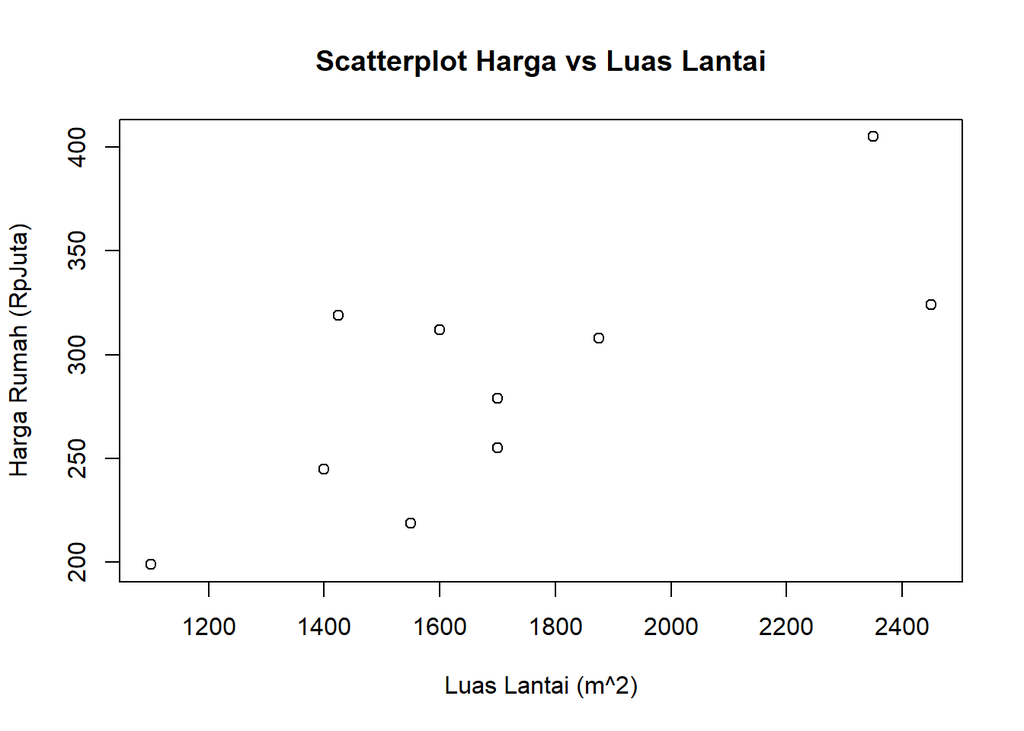

```r
#Input data
harga <- c(245, 312, 279, 308, 199, 219, 405, 324, 319, 255)
luas <- c(1400, 1600, 1700, 1875, 1100, 1550, 2350, 2450, 1425, 1700)

#Membuat Scatterplot
plot(x = luas, y = harga,
     main = "Scatterplot Harga vs Luas Lantai", xlab = "Luas Lantai (m^2)",
     ylab = "Harga Rumah (RpJuta)")
```

```r
#Koefisien Korelasi
cor(luas, harga, method = "pearson")
```

```
## [1] 0.7621137
```

```r
#Matriks Korelasi
df <- data.frame(luas, harga)
korelasi <- cor(df)
korelasi
```

```
##            luas     harga
## luas  1.0000000 0.7621137
## harga 0.7621137 1.0000000
```

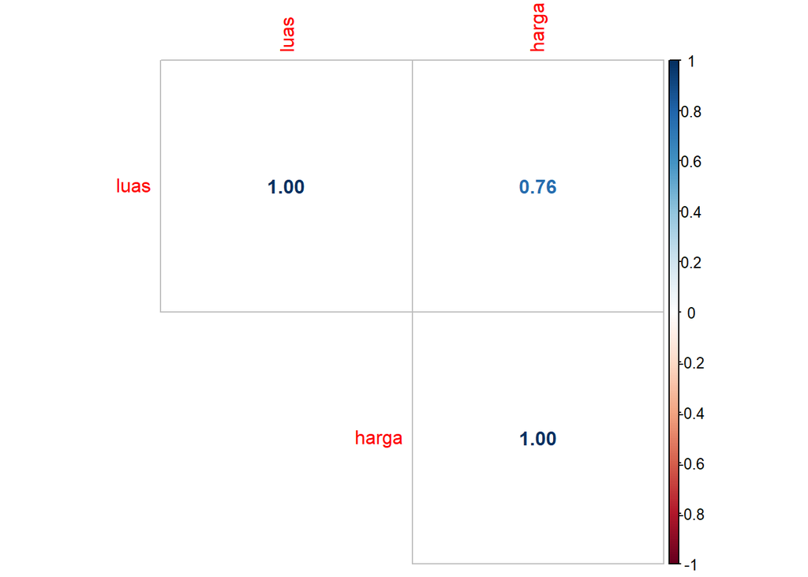

```r
#install.packages("corrplot")
library(corrplot)
corrplot(corr = korelasi, method = "number", type = "upper")
```

```r
#Uji Signifikansi Koefisien Korelasi
#Hipotesis H0: rho = 0 vs H1: rho ≠ 0
cor.test(x = luas, y = harga, alternative = "two.sided", method = "pearson", exact = NULL, conf.level = 0.95)
```

```
##
##  Pearson's product-moment correlation
##
## data:  luas and harga
## t = 3.3294, df = 8, p-value = 0.01039
## alternative hypothesis: true correlation is not equal to 0
## 95 percent confidence interval:
##  0.2547085 0.9404622
## sample estimates:
##       cor
## 0.7621137
```

Nilai p (p-value = 0.01039): Karena nilai p < 0.05, kita menolak hipotesis nol dan menyimpulkan bahwa ada korelasi yang signifikan antara Luas Lantai dan Harga Rumah

## Analisis Regresi

Model Deterministik vs Stokhastik

Misalkan diketahui:

- $X = 1$, $Y = 3$
- $X = 4$, $Y = 9$

Diberikan fungsi deterministik:

$$f(X) = 1 + 2X$$

**Pertanyaan:**

- Berapa $Y$ jika $X = 2$? → Pasti $Y = 5$
- Berapa $Y$ jika $X = 3$? → Pasti $Y = 7$

100% kita percaya bahwa nilai $Y = 5$ dan $Y = 7$ adalah satu-satunya nilai untuk $X = 2$ dan $X = 3$.

- $Y$ nilainya pasti, bebas dari error
- $Y$ bukan peubah acak

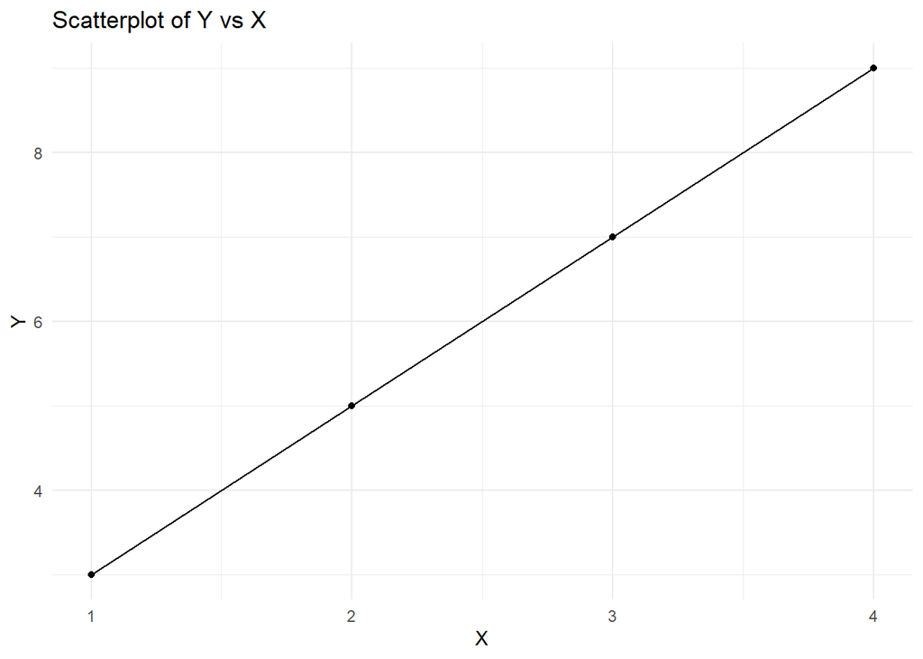

Untuk setiap dosis pupuk yang dicobakan, banyaknya padi yang dihasilkan diamati sebanyak 3 kali. Hasilnya pada tabel di samping.

| X | Y |
| --- | --- |
| 1 | 3.0 |
| 1 | 3.4 |
| 1 | 2.8 |
| 2 | 5.0 |
| 2 | 5.4 |
| 2 | 4.7 |
| 3 | 7.0 |
| 3 | 7.3 |
| 3 | 6.6 |
| 4 | 9.0 |
| 4 | 9.3 |
| 4 | 8.5 |

Ternyata hasilnya (Y) tidak pasti.

→ mengandung error

→ Y Peubah Acak.

MODEL STOKHASTIK

$$Y = 1 + 2x + \varepsilon, \, \varepsilon = \text{error}$$

$$y_i = 1 + 2x_i + \varepsilon_i, \, \varepsilon_i = \text{error ke-} i$$

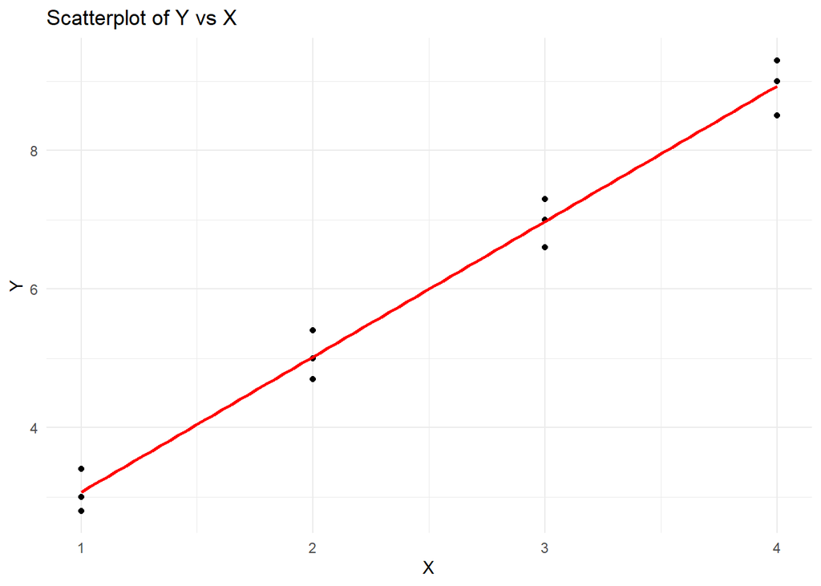

```r
data <- data.frame(
  X = c(1, 1, 1, 2, 2, 2, 3, 3, 3, 4, 4, 4),
  Y = c(3, 3.4, 2.8, 5, 5.4, 4.7, 7, 7.3, 6.6, 9, 9.3, 8.5)
)

# Scatterplot
ggplot(data, aes(x = X, y = Y)) +
  geom_point() +
  geom_smooth(method = "lm", se = FALSE, color = "red") +
  labs(
    x = "X",
    y = "Y",
    title = "Scatterplot of Y vs X"
  ) +
  theme_minimal()
```

# Latihan Soal

Diduga ada hubungan antara jumlah halaman buku yang digunakan dengan harga jual bukunya. Untuk menjawab dugaan tersebut dipilih sampel dari delapan buku yang dijual di toko tersebut.

Pertanyaan:

1. Buatlah **scatterplot** dan hitung **koefisien korelasinya**!
2. Apakah korelasi tersebut **signifikan**? Jelaskan!

Data:

| Book | Page | Price ($) |
| --- | --- | --- |
| Intro to History | 500 | 84 |
| Basic Algebra | 700 | 75 |
| Intro to Psyc | 800 | 99 |
| Intro to Sociology | 600 | 72 |
| Bus. Mngt | 400 | 69 |
| Intro to Biology | 500 | 81 |
| Fund. of Jazz | 600 | 63 |
| Princ. of Nursing | 800 | 93 |

```r
#Data
buku <- data.frame(
  Book = c("Intro to History", "Basic Algebra", "Intro to Psyc",
           "Intro to Sociology", "Bus. Mngt", "Intro to Biology",
           "Fund. of Jazz", "Princ. of Nursing"),
  Page = c(500, 700, 800, 600, 400, 500, 600, 800),
  Price = c(84, 75, 99, 72, 69, 81, 63, 93)
)
buku
```

```
##                 Book Page Price
## 1   Intro to History  500    84
## 2      Basic Algebra  700    75
## 3      Intro to Psyc  800    99
## 4 Intro to Sociology  600    72
## 5          Bus. Mngt  400    69
## 6   Intro to Biology  500    81
## 7      Fund. of Jazz  600    63
## 8  Princ. of Nursing  800    93
```

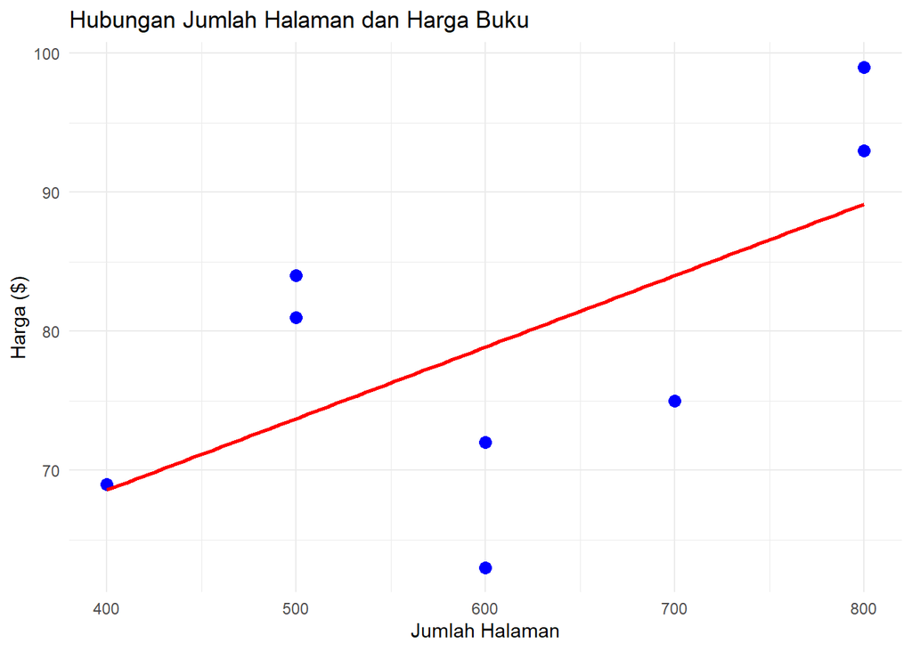

```r
#Scatterplot
ggplot(buku, aes(x = Page, y = Price)) +
  geom_point(color = "blue", size = 3) +
  geom_smooth(method = "lm", se = FALSE, color = "red") +
  labs(title = "Hubungan Jumlah Halaman dan Harga Buku",
       x = "Jumlah Halaman",
       y = "Harga ($)") +
  theme_minimal()
```

```r
#Koefisien Korelasi
cor_coef <- cor(buku$Page, buku$Price, method = "pearson")
cat("Koefisien Korelasi Pearson =", round(cor_coef, 3))
```

```
## Koefisien Korelasi Pearson = 0.614
```

**Hasil:**

```r
#Uji Signifikansi Koefisien Korelasi
cor_test <- cor.test(buku$Page, buku$Price)
cat("Hasil Uji Korelasi:\n")
```

```
## Hasil Uji Korelasi:
```

```r
cat("t-value =", round(cor_test$statistic, 3), "\n")
```

```
## t-value = 1.905
```

```r
cat("p-value =", format.pval(cor_test$p.value, eps = 0.001), "\n")
```

```
## p-value = 0.10546
```

```r
cat("Derajat Kebebasan (df) =", cor_test$parameter)
```

```
## Derajat Kebebasan (df) = 6
```